# Exploratory Data Work for the bank dataset

Feng Ruiwan <sub><Email:feng0107@e.ntu.edu.sg></sub>

Oct 2019

# Finding 1

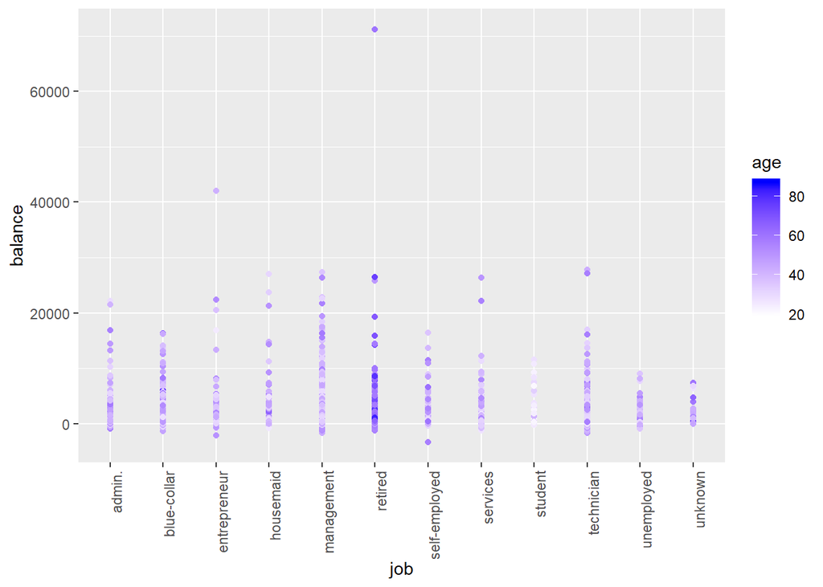

```r
ggplot(bank, aes(job, balance, color = age)) +
  geom_point() +
  scale_colour_gradient(low="white", high="blue") +
  theme(axis.text.x = element_text(angle = 90, hjust = 1))
```

# Finding 2

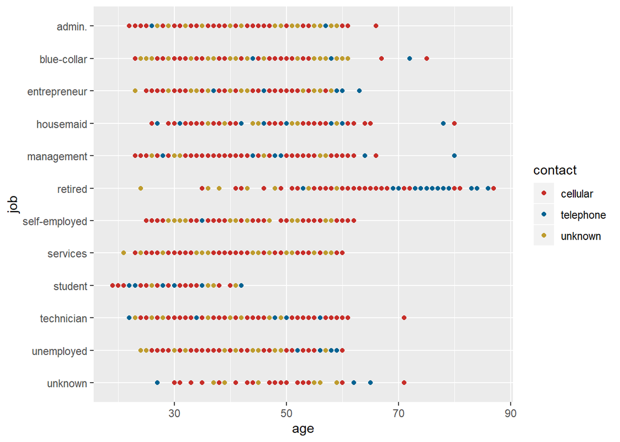

```r
ggplot(bank, aes(age, job, color = contact)) +
  geom_point() + scale_colour_wsj() +
  scale_y_discrete(limit = rev(levels(bank$job)))
```

**Most people have a cellular contact type, although the aged(>70) are more like ly to have a telephone one**

# Finding 3

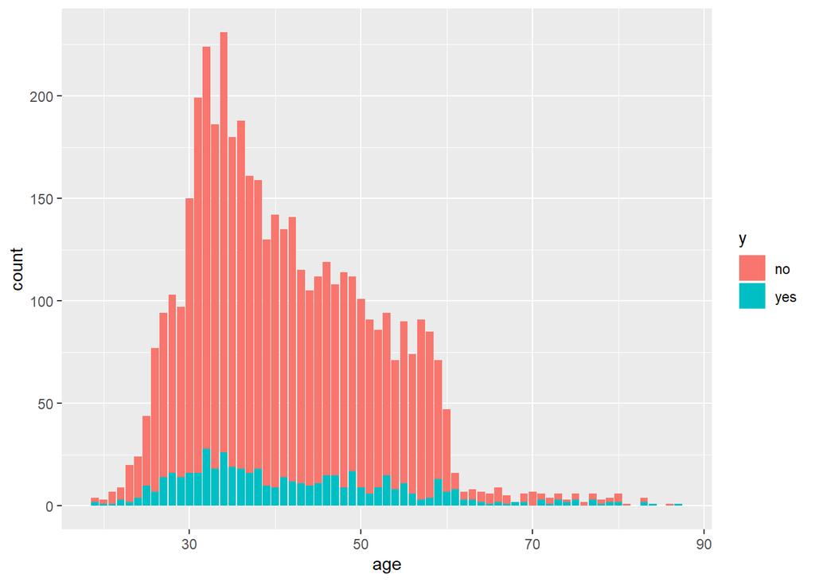

```r
ggplot(bank) + geom_bar(mapping = aes(x = age, fill = y))
```

**Most people in this dataset are between 30 and 40, although the number of people subscribed are not varing too much through different age.**

# Finding 4

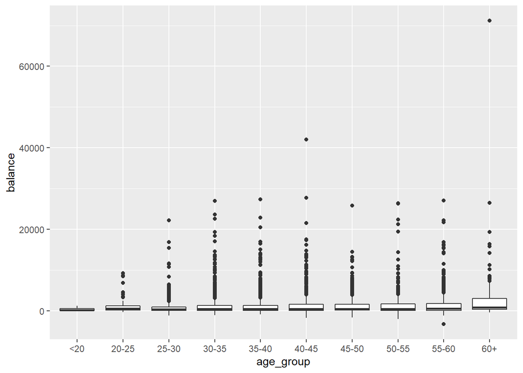

```r
df <- mutate(bank, age_group = case_when(
  age < 20 ~ "<20",
  age < 25 ~ "20-25",
  age < 30 ~ "25-30",
  age < 35 ~ "30-35",
  age < 40 ~ "35-40",
  age < 45 ~ "40-45",
  age < 50 ~ "45-50",
  age < 55 ~ "50-55",
  age < 60 ~ "55-60",
  TRUE ~ "60+"
)) %>%
  arrange(age_group)
ggplot(df, aes(age_group, balance)) + geom_boxplot()
```

# Finding 5

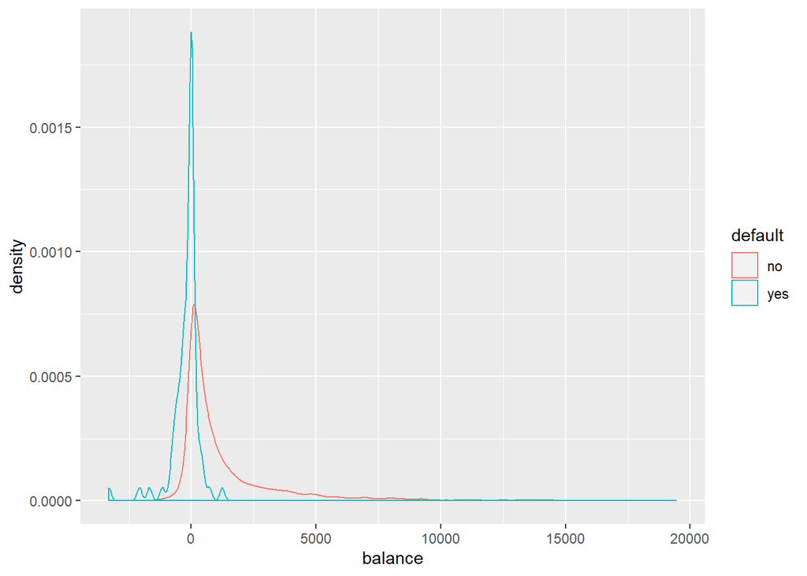

```r
df <- bank %>% filter(balance < 20000)
ggplot(df, aes(balance, color = default)) + geom_density()
```

**Peole with balance between 0 and 2000 are more likely to have default credit.**

# Finding 6

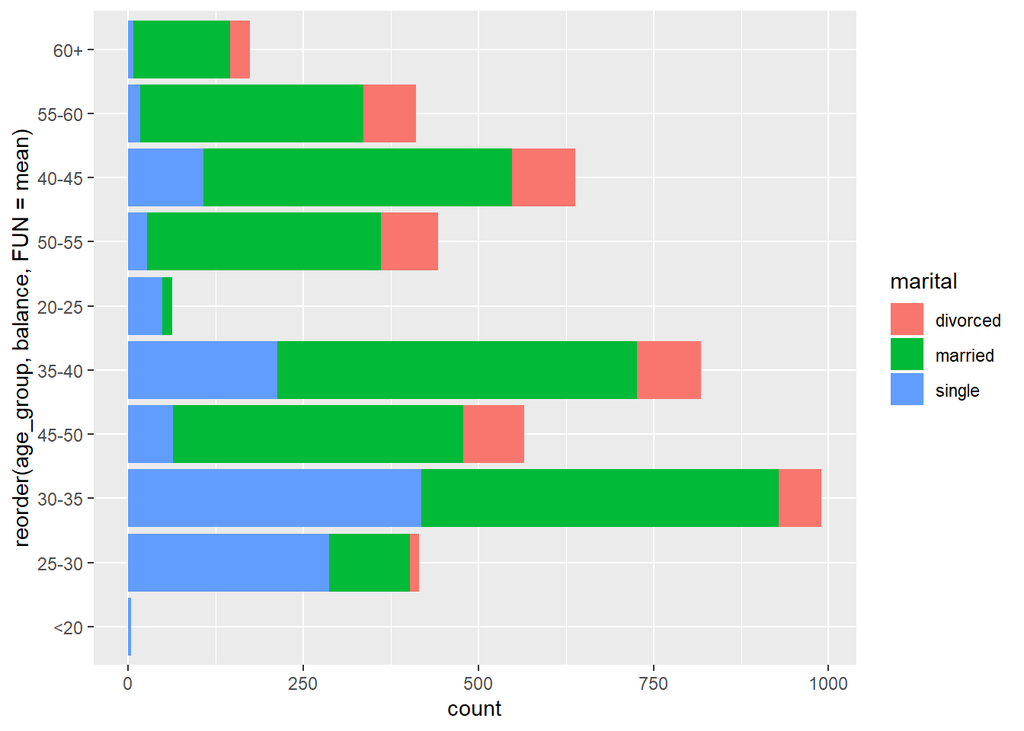

```r
df <- mutate(bank, age_group = case_when(
  age < 20 ~ "<20",
  age < 25 ~ "20-25",
  age < 30 ~ "25-30",
  age < 35 ~ "30-35",
  age < 40 ~ "35-40",
  age < 45 ~ "40-45",
  age < 50 ~ "45-50",
  age < 55 ~ "50-55",
  age < 60 ~ "55-60",
  TRUE ~ "60+"
))
ggplot(df, mapping = aes(x = reorder(age_group, balance, FUN = mean), fill = marital)) +
  geom_bar() + scale_colour_wsj() +
  coord_flip()
```

**Peole older than 40 tend to have more balance. Since 35, most people are more likely to getting married.**

# Finding 7

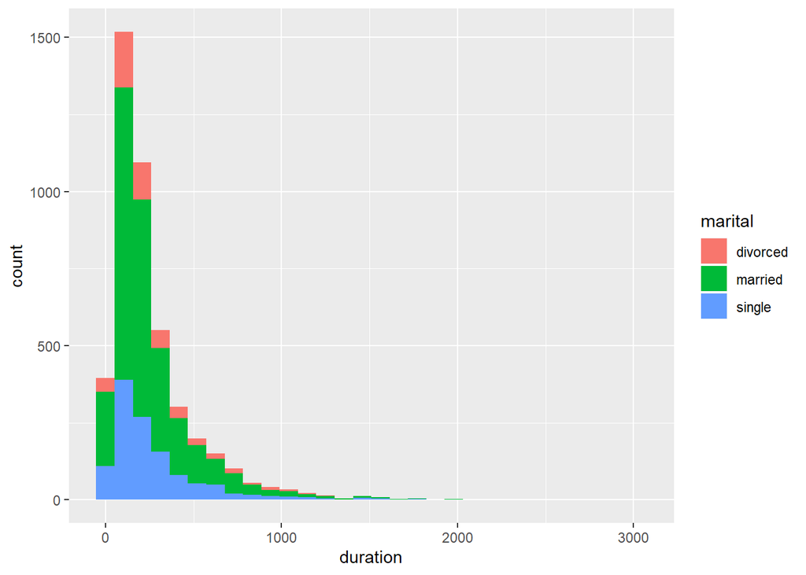

```r
ggplot(bank, mapping = aes(x = duration, fill = marital)) + geom_histogram()
## `stat_bin()` using `bins = 30`. Pick better value with `binwidth`.
```

**Duration for most people are less than 500, and is not so correlated with their marital status.**

# Finding 8

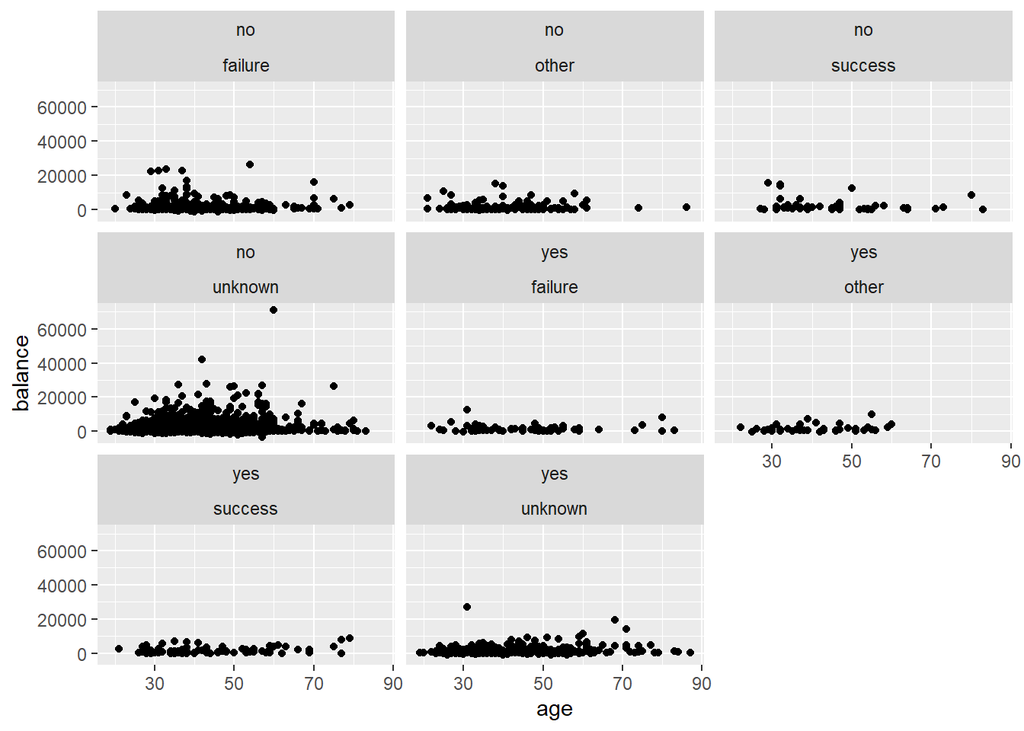

```r
ggplot(bank) +
  geom_point(mapping = aes(x = age, y = balance)) +
  facet_wrap( y ~ poutcome )
```

# Finding 9

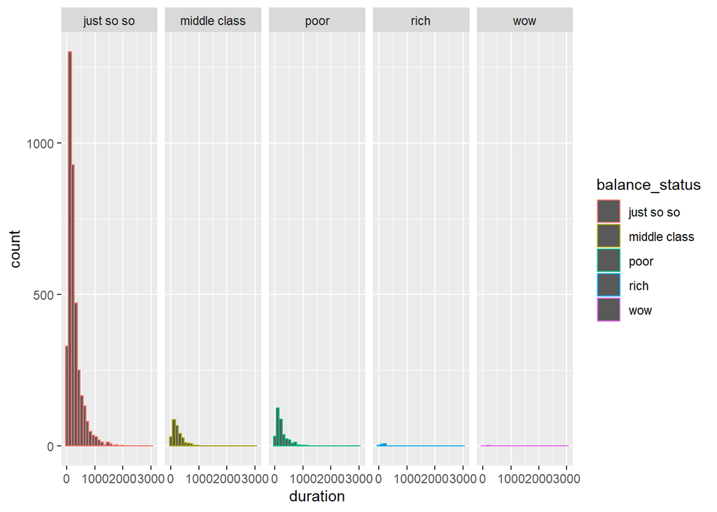

```r
df <- mutate(bank, balance_status = case_when(
  balance < 0 ~ "poor",
  balance < 5000 ~ "just so so",
  balance < 20000 ~ "middle class",
  balance < 30000 ~ "rich",
  TRUE ~ "wow"
))
ggplot(df, aes(duration)) + geom_histogram(aes(color = balance_status)) +
  facet_grid(.~balance_status)
## `stat_bin()` using `bins = 30`. Pick better value with `binwidth`.
```

**Most people own balance between 0-5000, and distribution of duration doesn’t change to much across balance status group, most duration are less than 500.**

# Finding 10

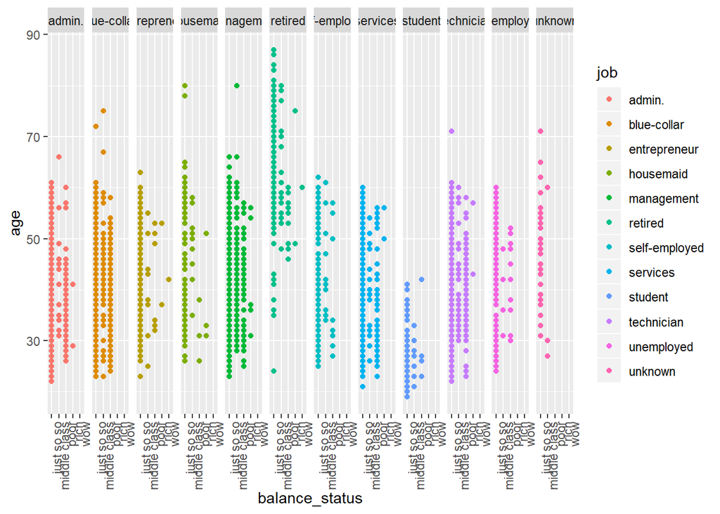

```r
df <- mutate(bank, balance_status = case_when(
  balance < 0 ~ "poor",
  balance < 5000 ~ "just so so",
  balance < 20000 ~ "middle class",
  balance < 30000 ~ "rich",
  TRUE ~ "wow"
))
ggplot(df, aes(balance_status, age)) + geom_point(aes(color = job)) +
  facet_grid(.~job) +
  theme(axis.text.x = element_text(angle = 90, hjust = 1))
```

**Except student and retired people, other jobs do not have certain age features. In administion, blue-collar, service and technical sector, there are more people with balance less than 0. Most middle class are in management sector.**